# error-validation1

November 28, 2018

## Overview

This document summarizes some preliminary work predicting and validating uncertainty in SWOT height measurements, using the SWOT instrument simulator and geodem height data from the Sacramento river.

## Dataset

The PIXC simulator output contains approximately 520000 pixels from the Sacramento River, corresponding to 756 SWOT nodes. The pixel data include numerous fields, including location, classification (land, water, etc.), number of looks, height sensitivity, interferogram components (real and imaginary), and radar power. A random sample of size 10000 from the pixel cloud is shown below

## Dataset

[interactive chart not shown]

## Water and water-near-land only

[interactive chart not shown]

## Zoomed in

Here is the full pixel cloud for the 2 northernmost nodes (colored by node).

[interactive chart not shown]

## Zoomed in

The same location, colored by pixel classification.

[interactive chart not shown]

## Theory

Interferometric phase variance is approximated by the Cramer-Rao lower bound given in Rodriguez and Martin (1992):

\[ \sigma^2_\phi = \frac{1}{2 N_L}\frac{1 - \gamma^2}{\gamma^2} \]

This is converted to variance of height error by scaling by the height sensitivity, \(d_h\).

\[ \sigma^2_h = d_h^2\sigma_\phi^2 \]

## Pixel-scale results

Height residuals density plot (empirical)

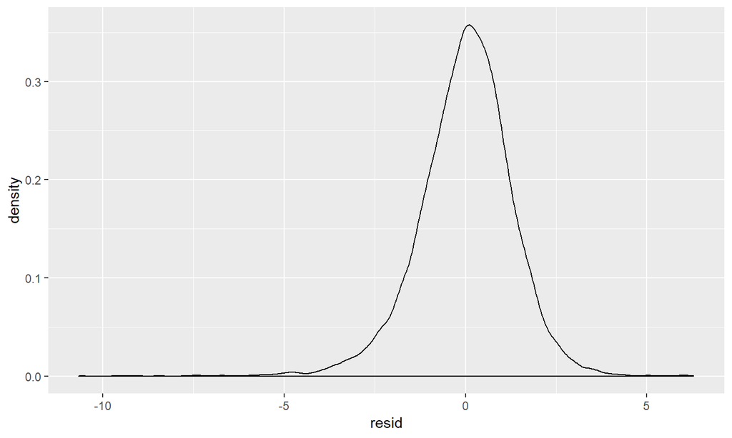

## Error model validation

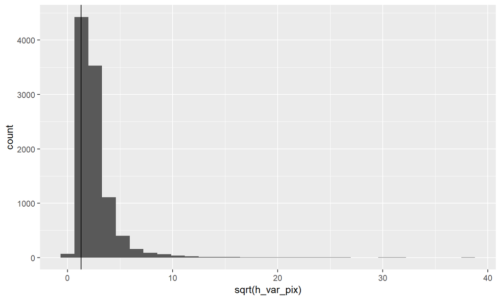

## Error model validation

While the variance model has some skill in predicting the pixel height error magnitude, it severely overestimates the error variance except for the smallest variance estimates.

## Validation residuals, predicted standard deviation

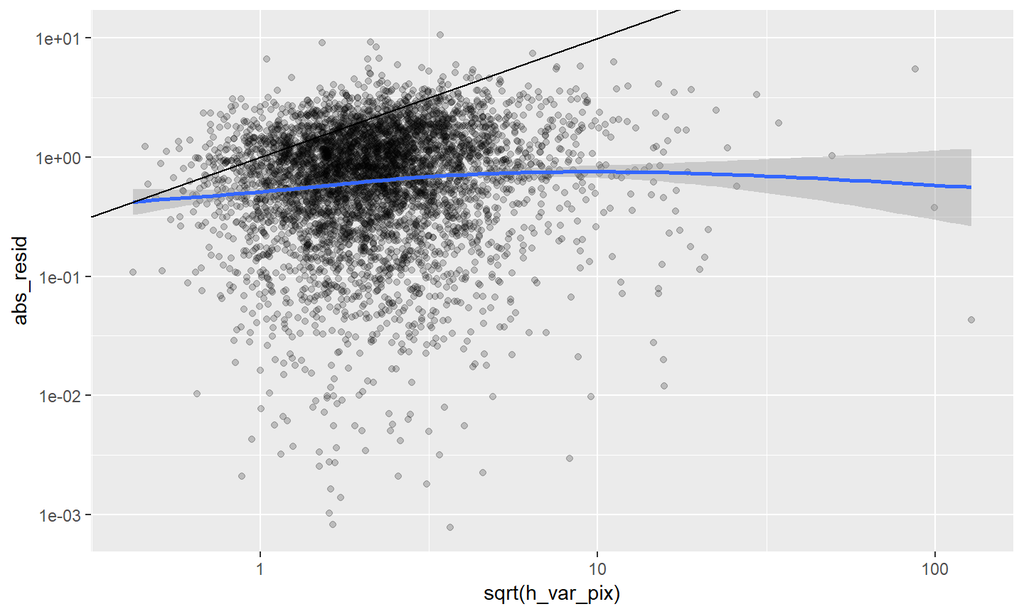

## Squared validation residuals, predicted variance

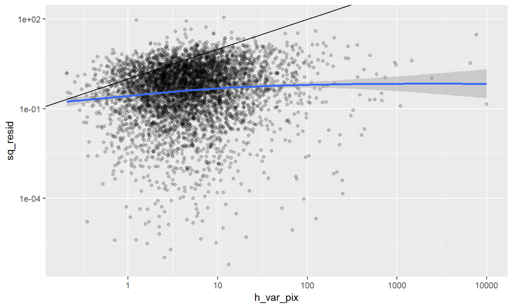

## Empirical variance validation by decile of prediction

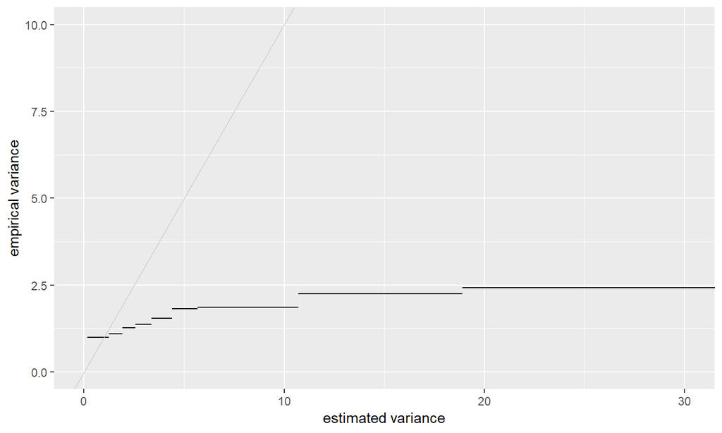

## Errors by cross-track distance

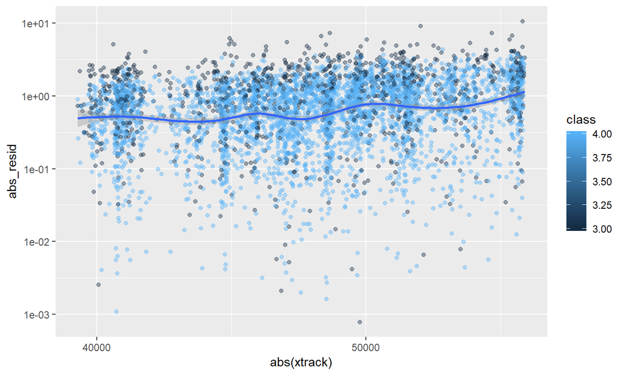

## Errors by height sensitivity

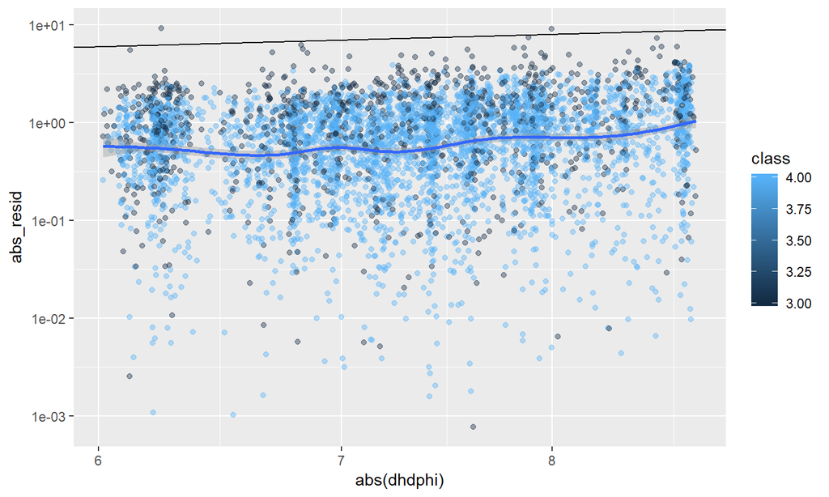